# Coursework Report

*N* removed NAs: 3

*N* removed typo: 1

*N* removed <18: 25

*N* total clean: 121

| Group | *N* | *M*<sub>age</sub> | *M*<sub>rating</sub> |
| --- | --- | --- | --- |
| Control | 60 | 20.93 | 6.80 |
| Experim | 61 | 21.30 | 5.38 |

**Main analysis results**

*t*(119) = 10.23, *p* < .001

[interactive chart not shown]

[figure not shown]

[interactive chart not shown]

# Coursework Report

Analysing Data, Spring 2020

# Methods

## Participants

Originally, a total of 150 participants took part in the experiment. For the white (control) condition, ages ranged between 18-25, with a mean age of 20.93. The age of participants in the red (experimental) condition ranged between 18-29, and had a mean age of 21.30. As figure. 1 shows, the standard deviation (SD) of participant age was 1.89 for the control group, and 2.40 for the experimental group.

*Figure.1* Descriptive statistics of ages by condition

| Condition | *N* | *M*<sub>age</sub> | *SD*<sub>age</sub> | *Min*<sub>age</sub> | *Max*<sub>age</sub> |
| --- | --- | --- | --- | --- | --- |
| White | 60 | 20.93 | 1.89 | 18 | 25 |
| Red | 61 | 21.30 | 2.40 | 18 | 29 |

In total, the data from 29 participants were omitted from the experiment; three of these were due to missing data and one was caused by data inaccuracy (a typing error). The exclusion of the remaining 25 were the result of ethical concerns; the participants were under the age of 18. Overall, the data from 121 participants were included. Sixty-one of the 121 participants were part of the red (experimental) condition.

## Design

The conceptual hypothesis for this experiment is that attractiveness is affected by colour. The research question is therefore as follows: does colour affect perceived attractiveness?

The independent variable in this experiment was colour. This factor consisted of two levels: red (experimental condition), and white (control condition). The dependent variable was attractiveness; measured using a nine-point scale where higher ratings correspond to higher levels of attractiveness. Attractiveness was judged using three questions: ‘how attractive do you think this person is?’, how pleasant is this face to look at?‘, and if I were to meet the person in this picture face to face, I would find them attractive’.

The operationalised hypothesis is that the addition of a different pigmented background onto the picture of a man will influence his perceived attractiveness (mean attractiveness rating). To test the operationalised hypothesis, a two-sample t-test will be carried out. This statistical analysis will be used as the experimental and control group are independent from one another, and therefore can be said to come from different populations.

# Results

It was necessary to alter several data points. As mentioned previously, all participants under the age of 18 were filtered out and removed in accordance with ethical guidelines. New variables also had to be created. A typographical error had allowed data to be placed under an ‘expeimental’ variable, which had to be recoded and corrected. A similar situation had created the variable ‘1r’. This was first recoded to ‘1’, and was then removed as the true age of the participant it belonged to was unknown. The variables ‘experimental’ and ‘control’ were also recoded to ‘red’ and ‘white’ respectively. A mean score was also generated for each attractiveness question, which were then collaborated to generate the overall mean attractiveness rating for both the red, and white, condition. This is the composite score.

*Figure.2* Descriptive statistics of attractiveness scores by condition

| Condition | *N* | *M*~attractiveness score~ | *SD*~attractiveness score~ | *Min*~attractiveness score~ | *Max*~attractiveness score~ |
| --- | --- | --- | --- | --- | --- |
| White | 60 | 6.80 | 0.74 | 5.33 | 8.67 |
| Red | 61 | 5.38 | 0.78 | 3.00 | 7.00 |

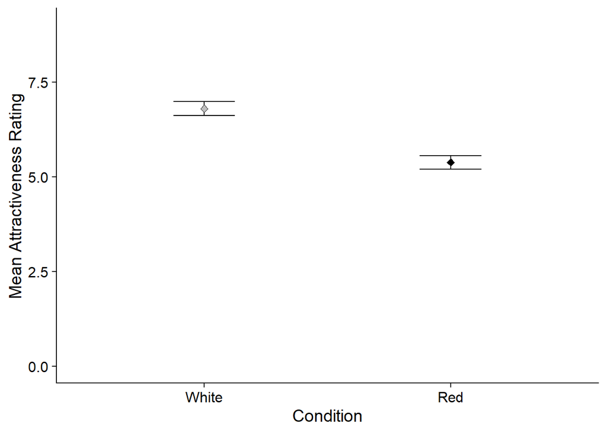

The results of the two-sample t-test are as follows: the means for the white and red group were (*M* = 6.8 and *M* = 5.38) respectively, with a difference of (*M*<sub>diff</sub> = 1.42). It was found that this difference in means was significant (95% CI [1.14, 1.69], *t* (119) = 10.23, *p* = 0).

The low p-value, and the rather high t-value, implies that it is unlikely that the two sample means come from the same population; suggesting that the two sample means came from different populations. The significant result means that the null hypothesis (that different coloured backgrounds have no effect on attractiveness) can be rejected.

# Discussion

Results found a substantial difference between the mean perceived attractiveness for the white-backed control image as compared to the red-backed experimental image (*M* = 6.8, *M* = 5.38). Further statistical analysis showed that this difference was significant (95% CI [1.14, 1.69], *t* (119) = 10.23, *p* = 0). The male was rated as more attractive when he was presented alongside the white background compared to the red. This experiment set out to gain insight into the following question: does colour affect perceived attractiveness? The result from the experiment supports the concept that colour can influence perceived attractiveness; the presence of colour appears to decrease male attractiveness.

This colour effect has also been found in other research (Guéguen & Jacob, 2013; Kim & Velando, 2014; Elliot et al., 2010), lending support to the hypothesis that colour can influence attraction. However, although it is quite clear that this effect exists, other research suggests that colour increases, rather than decreases, attractiveness.

While researching stickleback fish, Kim and Velando (2014) found the males would elevate their red colouration when competing for mates, suggesting that the colour red is more appealing to the female stickleback fish. Similarly, Guéguen and Jacob (2013) found that women were approached more frequently on dating sites if they were accompanied by the colour red, as compared to other colours including yellow, green, and white. Elliot et al., (2010) established that women rated a male as significantly more attractive in a red-backed image condition than a white-backed image condition (M = 6.79 and M = 5.67 respectively). The current study however, found the opposite effect. Red was found to be perceived as less attractive than white. This study was a direct replication of Elliot et al., (2010) yet found opposite results. This raises doubt about the replicability of the colour effect, and also raises questions about how the mechanism behind it functions if opposite results are found. This means that further research is needed in order to establish both if the replication failure is due to a methodological problem or if the different results are the product of a complex mechanism.

This experiment is limited in several ways. To begin with, only the colours red and white were tested. White was used as the control as it was considered the mutest, and most contrastable colour to red (Elliot et al., 2010). The exclusion of a vast array of colours means that the results are limited and therefore difficult to generalise. It is hard to make the bold claim that colours influence attractiveness when only one was tested. Other explanations for the result could be that the colour red is unique in its effects on attractiveness. Another weakness of the experiment is that it doesn’t explore the possible mechanisms behind the effect. Other research results suggest that the effect is caused by the association of red with dominance, and sexual promiscuity (Khan, Levine, Dobson & Kralik, 2011; Pazda et al., (2014) that increase perceptions of attractiveness respectively. However, this study failed to not only replicate previous results, but to explore any mechanism which may have been able to explain the difference.

As previously mentioned, the main limitation of the current experiment is that it did not provide any understanding of a mechanism behind the colour effect. Future research could therefore aim to understand the process behind colour and attractiveness. In Western countries especially, red is often linked to danger; with red being used in danger signs, stop signs, and alarm colours to name a few (Pravossoudovitch, Cury, Young & Elliot, 2014). In addition to this, Pravossoudovitch (2014) found that participants highly associated the colour red with danger. Red however, is also linked with romance, sex, and love (Elliot et al., 2010). It is possible that the failure to replicate Elliot et al., (2010) was caused by individual differences; specifically, differences in associations with the colour red that caused some participants to feel more attracted to the colour red, and others to be less so. Future research could establish, through self-report techniques, different ingrained associations with different colours and how those associations affect attractiveness ratings of a male linked to those colours. Another limitation of this experiment is that it only looked at the effect of one colour. Guéguen and Jacob (2013) found differences in attractiveness ratings of women wearing the colour yellow and black suggesting that it is not just red which has an effect. Future research should aim to look at a vast number of colours in order to ascertain more conclusively whether colour affects perceived attractiveness.

The present experiment set out to explore the question: does colour affect perceived attractiveness? It is clear that colour does influence how attractive someone is seen as being, with the colour red decreasing attraction. In gaining this result, further questions about the replicability of the colour effect have been raised, as well as the underlying mechanism behind it. Future research will need to explore possible explanations for this colour effect.

# References

Elliot, A.J., Niesta Kayser, D., Greitemeyer, T., Lichtenfeld, S., Gramzow, R.H., Maier, M.A., & Liu, H. (2010). Red, rank, and romance in women viewing men. *Journal of Experimental Psychology: General, 139*(3), 399-417. DOI: 10.1037/a0019689

Guéguen, N., & Jacob, C. (2013). Color and cyber-attractiveness: Red enhances men’s attraction to women’s internet personal ads. *Color Research & Application, 38*(4), 309-312. DOI: 10.1002/col.21718

Khan, S.A., Levine, W.J., Dobson, S.D., & Kralik, J.D. (2011). Red signals dominance in male rhesus macaques. *Psychological Science, 22*(8), 1001-1003. DOI: 10.1177/0956797611415543

Kim, S-Y., & Velando, A. (2014). Stickleback males increase red coloration and courtship behaviours in the presence of a competitive rival. *Ethology, 120*(5), 502-510. DOI: 10.1111/eth.12224

Pravossoudovitch, K., Cury, F., Young, S., & Elliot, A. (2014). Is red the colour of danger? Testing an implicit red-danger association. *Ergonomics, 57*(4), 503-510. DOI: 10.1080/00140139.2014.889220